# LoneWolf (U1800): Season 37

[figure not shown]

### Overview

This [season’s](https://www.lichess4545.com/lonewolf/season/37u1800/summary/) games were played between 27 May 2025 and 10 August 2025.

83 players participated, 31 (37%) of whom were new to the league.

In all, 284 games were played over the season. The season’s ‘unplayed pairing’ rate was 8.7%.[^1]

[figure not shown]

### Final standings

1st place

[GenTurgidson](https://www.lichess4545.com/lonewolf/season/37u1800/player/GenTurgidson/)

8.5/11 (1883 perf)

2nd place

[EnglishSpaniel](https://www.lichess4545.com/lonewolf/season/37u1800/player/EnglishSpaniel/)

8.5/11 (1881 perf)

3rd place

[shrockswole](https://www.lichess4545.com/lonewolf/season/37u1800/player/shrockswole/)

8/11 (1852 perf)

Best U1600

[shum13](https://www.lichess4545.com/lonewolf/season/37u1800/player/shum13/)

7.5/11 (1760 perf)

#### How the title race played out

[figure not shown]

#### Best scorers

Here’s everyone who achieved a plus score of +5 or higher this season[^3]:

**EnglishSpaniel** (8.5/11), **TTotr** (6/6), **GenTurgidson** (7.5/10)

Players with plus scores of +6 or better get the **Ace** award.

### Stats - overview

#### Timing

[figure not shown]

#### Length

[figure not shown]

#### Most moves

*Includes games ranked at or above the 90th percentile by number of moves.*

| Rank | Players / Link | Date | Moves |
| --- | --- | --- | --- |
| 1 | R0B-W - garrincha11 | Mon 9 Jun 2025 | 84 |
| 2 | ReyCebador - berndwind | Sat 2 Aug 2025 | 82 |
| 3 | mongreltiger - ViAaNjS | Wed 6 Aug 2025 | 81 |
| 4 | rjhoro - Gingersquirrelnuts | Thu 7 Aug 2025 | 79 |
| 5 | aiRini_h - Kborman | Sat 7 Jun 2025 | 75 |
| 6 | ilgulla - zajxajer | Wed 4 Jun 2025 | 74 |
| 7 | HamSamisch - metalpawn | Wed 25 Jun 2025 | 73 |
| 8 | EnglishSpaniel - shrockswole | Wed 16 Jul 2025 | 72 |
| 8 | BrunoMartens - kauberdi | Sat 14 Jun 2025 | 72 |
| 8 | DavidSifre - ogennadi | Fri 13 Jun 2025 | 72 |

[output cut: 12 more lines]

#### Longest games

*Includes games ranked at or above the 90th percentile by total clock time.*[^4]

| Rank | Players / Link | Date | Total time |
| --- | --- | --- | --- |
| 1 | rjhoro - Gingersquirrelnuts | Thu 7 Aug 2025 | 2h 7m 30s |
| 2 | aiRini_h - Kborman | Sat 7 Jun 2025 | 2h 4m 24s |
| 3 | BrunoMartens - kauberdi | Sat 14 Jun 2025 | 2h 2m 21s |
| 4 | HamSamisch - metalpawn | Wed 25 Jun 2025 | 2h 1m 4s |
| 5 | EnglishSpaniel - shrockswole | Wed 16 Jul 2025 | 2h 0m 24s |
| 6 | faxeleun - Catholicity | Sat 12 Jul 2025 | 1h 59m 27s |
| 7 | ReyCebador - berndwind | Sat 2 Aug 2025 | 1h 54m 4s |
| 8 | faxeleun - aQuafr3sh | Fri 27 Jun 2025 | 1h 53m 57s |
| 9 | jcarmody - aQuafr3sh | Wed 30 Jul 2025 | 1h 51m 2s |
| 10 | Gingersquirrelnuts - EnglishSpaniel | Fri 20 Jun 2025 | 1h 50m 26s |

[output cut: 12 more lines]

### Stats - by board/rating

#### ACPL and blunder rate

[figure not shown]

#### Lowest combined ACPL

The games with the lowest combined ACPL (including draws).

| Players / Link | Result | Sum ACPL | Date |
| --- | --- | --- | --- |
| EnglishSpaniel - shrockswole | 1/2-1/2 | 22 | Wed 16 Jul 2025 |
| shrockswole - ReyCebador | 1-0 | 26 | Wed 25 Jun 2025 |
| ekopp2000 - BrunoMartens | 1-0 | 28 | Thu 3 Jul 2025 |
| faxeleun - shum13 | 1/2-1/2 | 36 | Fri 18 Jul 2025 |
| garrincha11 - SChessNewbie | 1/2-1/2 | 36 | Fri 11 Jul 2025 |
| thinline69 - rjhoro | 1-0 | 37 | Fri 18 Jul 2025 |
| shum13 - KingofBongo64 | 1-0 | 39 | Sat 5 Jul 2025 |
| ogennadi - rjhoro | 0-1 | 39 | Sun 8 Jun 2025 |
| berndwind - ScienceGeek | 1-0 | 41 | Sun 10 Aug 2025 |
| EnglishSpaniel - ReyCebador | 0-1 | 41 | Fri 30 May 2025 |

#### Decisive games only

The *decisive* games with the lowest combined ACPL.

| Players / Link | Result | Sum ACPL | Date |
| --- | --- | --- | --- |
| shrockswole - ReyCebador | 1-0 | 26 | Wed 25 Jun 2025 |
| ekopp2000 - BrunoMartens | 1-0 | 28 | Thu 3 Jul 2025 |
| thinline69 - rjhoro | 1-0 | 37 | Fri 18 Jul 2025 |
| shum13 - KingofBongo64 | 1-0 | 39 | Sat 5 Jul 2025 |
| ogennadi - rjhoro | 0-1 | 39 | Sun 8 Jun 2025 |
| berndwind - ScienceGeek | 1-0 | 41 | Sun 10 Aug 2025 |
| EnglishSpaniel - ReyCebador | 0-1 | 41 | Fri 30 May 2025 |
| UpGoerFive - lukasil01 | 0-1 | 42 | Sat 19 Jul 2025 |
| jcarmody - HamSamisch | 0-1 | 43 | Sun 20 Jul 2025 |
| UpGoerFive - Lapastiere | 1-0 | 43 | Sat 21 Jun 2025 |

### Openings

#### First moves

The frequency of first move pairs by board (4545) or average rating band (LoneWolf).

[figure not shown]

#### Top openings

All openings played in the season, excluding variations.

| rank | opening.broad | games | perc_w | white_wins | draws | black_wins | mean_eval_after_15 | mean_rating |
| --- | --- | --- | --- | --- | --- | --- | --- | --- |
| 1 | Queen's Pawn Game | 39 | 43.5897435897436 | 38.4615384615385 | 10.2564102564103 | 51.2820512820513 | 0.832105263157895 | 1602.47435897436 |
| 2 | Caro-Kann Defense | 34 | 58.8235294117647 | 55.8823529411765 | 5.88235294117647 | 38.2352941176471 | 0.592121212121212 | 1664.70588235294 |
| 3 | Sicilian Defense | 26 | 40.3846153846154 | 38.4615384615385 | 3.84615384615385 | 57.6923076923077 | 0.452083333333333 | 1649.84615384615 |
| 4 | Indian Defense | 18 | NA | NA | NA | NA | 0.401176470588235 | 1626.72222222222 |
| 4 | Italian Game | 18 | 55.5555555555556 | 50 | 11.1111111111111 | 38.8888888888889 | 0.378235294117647 | 1597.63888888889 |
| 6 | French Defense | 16 | 50 | 50 | 0 | 50 | 0.160666666666667 | 1663.34375 |
| 7 | English Opening | 11 | 68.1818181818182 | 63.6363636363636 | 9.09090909090909 | 27.2727272727273 | 0.385 | 1622.77272727273 |
| 7 | Queen's Gambit Declined | 11 | 54.5454545454545 | 54.5454545454545 | 0 | 45.4545454545455 | 0.638181818181818 | 1744 |
| 9 | Rapport-Jobava System | 10 | 60 | 60 | 0 | 40 | 1.392 | 1600.55 |
| 10 | King's Indian Attack | 8 | 37.5 | 37.5 | 0 | 62.5 | 0.354285714285714 | 1667.9375 |

[output cut: 30 more lines]

#### Best for White

White’s top-scoring openings, excluding variations. *Minimum 10 games played.*

| rank | opening.broad | games | perc_w | white_wins | draws | black_wins | mean_eval_after_15 | mean_rating |
| --- | --- | --- | --- | --- | --- | --- | --- | --- |
| 1 | English Opening | 11 | 68.1818181818182 | 63.6363636363636 | 9.09090909090909 | 27.2727272727273 | 0.385 | 1622.77272727273 |
| 2 | Caro-Kann Defense | 34 | 58.8235294117647 | 55.8823529411765 | 5.88235294117647 | 38.2352941176471 | 0.592121212121212 | 1664.70588235294 |
| 3 | Italian Game | 18 | 55.5555555555556 | 50 | 11.1111111111111 | 38.8888888888889 | 0.378235294117647 | 1597.63888888889 |
| 4 | Queen's Gambit Declined | 11 | 54.5454545454545 | 54.5454545454545 | 0 | 45.4545454545455 | 0.638181818181818 | 1744 |
| 5 | French Defense | 16 | 50 | 50 | 0 | 50 | 0.160666666666667 | 1663.34375 |
| 6 | Queen's Pawn Game | 39 | 43.5897435897436 | 38.4615384615385 | 10.2564102564103 | 51.2820512820513 | 0.832105263157895 | 1602.47435897436 |
| 7 | Sicilian Defense | 26 | 40.3846153846154 | 38.4615384615385 | 3.84615384615385 | 57.6923076923077 | 0.452083333333333 | 1649.84615384615 |
| NA | Indian Defense | 18 | NA | NA | NA | NA | 0.401176470588235 | 1626.72222222222 |

#### Best for Black

Black’s top-scoring openings, excluding variations. *Minimum 10 games played.*

| rank | opening.broad | games | perc_b | black_wins | draws | white_wins | mean_eval_after_15 | mean_rating |
| --- | --- | --- | --- | --- | --- | --- | --- | --- |
| 1 | Sicilian Defense | 26 | 59.6153846153846 | 57.6923076923077 | 3.84615384615385 | 38.4615384615385 | 0.452083333333333 | 1649.84615384615 |
| 2 | Queen's Pawn Game | 39 | 56.4102564102564 | 51.2820512820513 | 10.2564102564103 | 38.4615384615385 | 0.832105263157895 | 1602.47435897436 |
| 3 | French Defense | 16 | 50 | 50 | 0 | 50 | 0.160666666666667 | 1663.34375 |
| 4 | Queen's Gambit Declined | 11 | 45.4545454545455 | 45.4545454545455 | 0 | 54.5454545454545 | 0.638181818181818 | 1744 |
| 5 | Italian Game | 18 | 44.4444444444444 | 38.8888888888889 | 11.1111111111111 | 50 | 0.378235294117647 | 1597.63888888889 |
| 6 | Caro-Kann Defense | 34 | 41.1764705882353 | 38.2352941176471 | 5.88235294117647 | 55.8823529411765 | 0.592121212121212 | 1664.70588235294 |
| 7 | English Opening | 11 | 31.8181818181818 | 27.2727272727273 | 9.09090909090909 | 63.6363636363636 | 0.385 | 1622.77272727273 |
| NA | Indian Defense | 18 | NA | NA | NA | NA | 0.401176470588235 | 1626.72222222222 |

#### Top gambits

The most played gambits over the season.[^5]

| Rank | Name | Games | White score (%) |
| --- | --- | --- | --- |
| 1 | Evans Gambit | 3 | 0 |
| 2 | Scotch Gambit | 2 | 75 |
| 3 | Anti-Moscow Gambit | 1 | 100 |
| 3 | King's Gambit | 1 | 100 |
| 3 | Meitner-Mieses Gambit | 1 | 100 |
| 4 | Löhn Gambit | 1 | 50 |
| 5 | Geller Gambit | 1 | 0 |
| 5 | Milner-Barry Gambit | 1 | 0 |
| 5 | Polerio Defense (Two Knights) | 1 | 0 |
| 5 | Queen's Gambit Accepted | 1 | 0 |

[output cut: 4 more lines]

#### Gambiteers

The players who enjoyed the most success when playing gambits.[^6] *Includes everyone who scored at least 50 per cent across at least two gambit games.*

```
## There were no deserving gambiteers this season :(
```

### Openings sunburst

Click on the image below to see a sunburst plot of all openings played in the season.

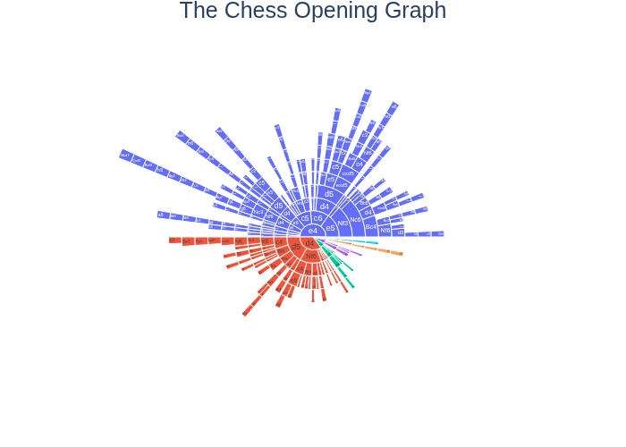

### Awards

Assorted awards to celebrate the season - see the footnote for more details.[^7]

| Award | Name / Description | Winner(s) | Runner(s)-up |
| --- | --- | --- | --- |
| x | Aces | EnglishSpaniel, TTotr |  |
| x | Archbishop of Accuracy | TTotr | ZACKONTRACK, EnglishSpaniel |
| x | Bullet Boss | ChessisHard101 | jcarmody, Asturc0n |
| x | David Award | GenTurgidson | shrockswole, UpGoerFive |
| x | Gambit Guru |  |  |
| x | Giri Award | PsyMar2, SChessNewbie, aQuafr3sh, aiRini_h, egolessaction, faxeleun, garrincha11, ogennadi, rjhoro |  |
| x | Grischuk's Cousin | Kborman | Kborman, casual921 |
| x | Houdini Award | IcyDylan2016 | rjhoro, thinline69 |
| x | Intimate with Increment | Kborman | aQuafr3sh, casual921 |
| x | MVP Award | TTotr | IcyDylan2016, shrockswole |

[output cut: 9 more lines]

### Stats - tables

Tons of detailed stats for your reading pleasure. All tables in this section are sortable and searchable - feel free to explore!

#### Best performances / highest accuracy

##### Best relative performances

This table shows players’ *relative* performance ratings – that is, their performance rating over the season minus their initial rating before their first game.[^8] *Includes everyone with a positive relative performance rating over at least five games.*

| # | Player | Games | W | D | L | Initial | Perf | Diff. |
| --- | --- | --- | --- | --- | --- | --- | --- | --- |
| 1 | TTotr | 6 | 6 | 0 | 0 | 1664 | 2388.16666666667 | 724.166666666667 |
| 2 | IcyDylan2016 | 11 | 6 | 1 | 4 | 1485 | 1811.90909090909 | 326.909090909091 |
| 3 | shrockswole | 9 | 6 | 1 | 2 | 1688 | 1920.55555555556 | 232.555555555556 |
| 4 | shum13 | 11 | 7 | 1 | 3 | 1584 | 1816.54545454545 | 232.545454545455 |
| 5 | Marco_Chess13 | 9 | 4 | 1 | 4 | 1443 | 1638 | 195 |
| 6 | GenTurgidson | 10 | 7 | 1 | 2 | 1759 | 1946.5 | 187.5 |
| 7 | kauberdi | 8 | 6 | 0 | 2 | 1697 | 1882.875 | 185.875 |
| 8 | EnglishSpaniel | 11 | 8 | 1 | 2 | 1749 | 1932.81818181818 | 183.818181818182 |
| 9 | UpGoerFive | 11 | 7 | 0 | 4 | 1699 | 1820.36363636364 | 121.363636363636 |
| 10 | ChessisHard101 | 11 | 5 | 1 | 5 | 1531 | 1634.27272727273 | 103.272727272727 |

[output cut: 18 more lines]

##### Lowest ACPL

All players who played at least five games and achieved a season ACPL in the 20th percentile or below. Note that ‘season ACPL’ differs from Lichess game-wide ACPL figures, as it excludes opening moves as well as most moves played in objectively decided positions. See the footnote for full details.[^9] ACPLs based on Lichess’s published figures are provided for comparison purposes.

| Rank | Player | Games | Season ACPL | Lichess ACPL |
| --- | --- | --- | --- | --- |
| 1 | TTotr | 6 | 26.8666666666667 | 18.6788990825688 |
| 2 | ZACKONTRACK | 5 | 41.4907407407407 | 32.7260273972603 |
| 3 | EnglishSpaniel | 10 | 47.2987804878049 | 25.1932584269663 |
| 4 | GenTurgidson | 9 | 51.1349206349206 | 34.2996845425868 |
| 5 | KingofBongo64 | 8 | 51.5 | 28.5690376569038 |
| 6 | kauberdi | 8 | 54.3706896551724 | 38.8062283737024 |
| 7 | aiRini_h | 8 | 56.9239130434783 | 42.0268817204301 |
| 8 | UpGoerFive | 8 | 56.9550561797753 | 33.7288732394366 |
| 9 | thinline69 | 9 | 57.2849162011173 | 40.305912596401 |
| 10 | shum13 | 11 | 59.2272727272727 | 35.3365384615385 |

[output cut: 10 more lines]

#### Time spent / strongest opponents

##### Time spent

The 50 players who spent the most clock time over the season.

| Rank | Player | Games | Total time spent |
| --- | --- | --- | --- |
| 1 | aQuafr3sh | 9 | 7h 24m 29s |
| 2 | casual921 | 10 | 6h 55m 25s |
| 3 | Gingersquirrelnuts | 10 | 6h 51m 40s |
| 4 | Catholicity | 10 | 6h 49m 56s |
| 5 | HamSamisch | 10 | 6h 47m 33s |
| 6 | faxeleun | 9 | 6h 46m 1s |
| 7 | shrockswole | 9 | 6h 45m 6s |
| 8 | Kborman | 8 | 6h 41m 40s |
| 9 | EnglishSpaniel | 11 | 6h 40m 28s |
| 10 | shum13 | 11 | 6h 37m 11s |

[output cut: 40 more lines]

##### Time spent per move (after move 10)

Minimum 3 games played.

| Rank | Player | Games | Moves | Time spent per move | Percentile |
| --- | --- | --- | --- | --- | --- |
| 1 | amagad12 | 6 | 116 | 1m 34.5s | 73 |
| 2 | lukasil01 | 10 | 199 | 1m 22.0s | 72 |
| 3 | ekopp2000 | 9 | 204 | 1m 18.5s | 71 |
| 4 | hpors | 10 | 205 | 1m 18.4s | 70 |
| 5 | UpGoerFive | 10 | 177 | 1m 15.8s | 69 |
| 6 | casual921 | 10 | 205 | 1m 15.0s | 68 |
| 7 | KingofBongo64 | 9 | 142 | 1m 11.8s | 67 |
| 8 | Zaxman | 4 | 64 | 1m 9.9s | 66 |
| 9 | baberle | 3 | 74 | 1m 9.4s | 65 |
| 10 | Lapastiere | 7 | 100 | 1m 9.2s | 64 |

[output cut: 63 more lines]

##### Strength of schedule

The players who faced the best-scoring opponents over the season, when judged by their collective score over all their *other* games. *Suggested by Tranzoo.*

| # | Player | Opp Games | Opp Pts | Opp % |
| --- | --- | --- | --- | --- |
| 1 | GenTurgidson | 86 | 60.5 | 70.3488372093023 |
| 2 | shrockswole | 79 | 54 | 68.3544303797468 |
| 3 | UpGoerFive | 79 | 51 | 64.5569620253165 |
| 4 | ScienceGeek | 47 | 30 | 63.8297872340426 |
| 5 | shum13 | 84 | 53 | 63.0952380952381 |
| 6 | KingofBongo64 | 83 | 51.5 | 62.0481927710843 |
| 7 | rob625 | 30 | 18.5 | 61.6666666666667 |
| 8 | EnglishSpaniel | 94 | 57 | 60.6382978723404 |
| 9 | thinline69 | 82 | 49 | 59.7560975609756 |
| 10 | ReyCebador | 73 | 42 | 57.5342465753425 |

[output cut: 14 more lines]

#### Comebacks and upsets

##### Comebacks

The players who achieved the most significant comeback wins and draws over the season.[^10] *Suggested by Lou-E.*

| Rank | Player | CB Games | Wins from < -6 | Wins from < -3 | Draws from < -6 | Draws from < -3 |
| --- | --- | --- | --- | --- | --- | --- |
| 1 | IcyDylan2016 | 5 | 1 | 3 | 1 | 0 |
| 2 | rjhoro | 4 | 1 | 2 | 1 | 0 |
| 3 | thinline69 | 4 | 1 | 2 | 0 | 1 |
| 4 | Kborman | 3 | 1 | 2 | 0 | 0 |
| 4 | Marco_Chess13 | 3 | 1 | 2 | 0 | 0 |
| 6 | jcarmody | 3 | 0 | 3 | 0 | 0 |
| 6 | metalpawn | 3 | 0 | 3 | 0 | 0 |
| 8 | aiRini_h | 3 | 0 | 2 | 1 | 0 |
| 9 | Asturc0n | 2 | 1 | 1 | 0 | 0 |
| 9 | ZACKONTRACK | 2 | 1 | 1 | 0 | 0 |

[output cut: 45 more lines]

##### Biggest upsets

Everyone who defeated an opponent who outrated them by at least 100 points.

| Rank | Player | Upset Margin | Link |
| --- | --- | --- | --- |
| 1 | cjoselouise | 560 | https://lichess.org/k6qgqkfJ |
| 2 | cjoselouise | 491 | https://lichess.org/noFxP7fI |
| 3 | MTL2165 | 324 | https://lichess.org/WDDgQmIa |
| 4 | Mafia008 | 261 | https://lichess.org/kXPqSlst |
| 5 | dama_x_rey | 238 | https://lichess.org/2JehVSdA |
| 6 | ChessisHard101 | 230 | https://lichess.org/L11sNHwc |
| 7 | DavidSifre | 223 | https://lichess.org/9qGyAJD0 |
| 8 | Marco_Chess13 | 219 | https://lichess.org/0IP1qAeI |
| 9 | IcyDylan2016 | 217 | https://lichess.org/YJkLRbsJ |
| 10 | R0B-W | 214 | https://lichess.org/ev5etjVj |

[output cut: 31 more lines]

##### Repeated upsets

Everyone who achieved multiple wins over opponents rated at least 100 points higher.

| Rank | Player | Total Upset Margin | Upsets | Avg Upset Margin | Biggest Margin |
| --- | --- | --- | --- | --- | --- |
| 1 | cjoselouise | 1051 | 2 | 525.5 | 560 |
| 2 | IcyDylan2016 | 801 | 5 | 160.2 | 217 |
| 3 | Marco_Chess13 | 510 | 3 | 170 | 219 |
| 4 | laughingoctopus | 396 | 2 | 198 | 206 |
| 5 | dama_x_rey | 361 | 2 | 180.5 | 238 |
| 6 | MarekW78 | 344 | 2 | 172 | 197 |
| 7 | Catholicity | 265 | 2 | 132.5 | 155 |
| 8 | rjhoro | 264 | 2 | 132 | 143 |
| 9 | ilgulla | 214 | 2 | 107 | 109 |

#### Dawdlers and instant movers

##### Least time left after move 10

Players who had the least time left after only 10 moves…but still managed to win! *Suggested by Silkthewanderer.*

| Rank | Player | Time left after 10 moves | Link |
| --- | --- | --- | --- |
| 1 | Kborman | 13m 18s | https://lichess.org/pWB9jdOf#20 |
| 2 | Kborman | 13m 45s | https://lichess.org/5pDzj0q7#19 |
| 3 | casual921 | 16m 34s | https://lichess.org/Yf5ZRNNp#19 |
| 4 | shum13 | 16m 39s | https://lichess.org/VfIr4SOQ#20 |
| 5 | aQuafr3sh | 17m 11s | https://lichess.org/8LT8aZGJ#19 |
| 6 | jpokerflat | 17m 25s | https://lichess.org/WtPNGPiP#19 |
| 7 | kmaddox86 | 18m 42s | https://lichess.org/XWb7yx0i#20 |
| 8 | ReyCebador | 19m 2s | https://lichess.org/BqnnUtHY#20 |
| 9 | faxeleun | 19m 8s | https://lichess.org/d6s7AfI9#19 |
| 10 | KingofBongo64 | 19m 9s | https://lichess.org/uDpXRT3U#20 |

##### Instant moves

Players who made at least five ‘instant’ moves (in under 0.5s), including pre-moves.

| Rank | Player | Instant moves |
| --- | --- | --- |
| 1 | ChessisHard101 | 12 |
| 1 | jcarmody | 12 |
| 3 | Asturc0n | 8 |
| 3 | IcyDylan2016 | 8 |
| 3 | ekopp2000 | 8 |
| 6 | Marco_Chess13 | 7 |
| 7 | aiRini_h | 6 |

#### Long thinks, lucky escapes, time trouble/travel, most moves

##### Longest thinks

The longest times spent on a single move.

*Top 100 shown.*

| # | Player | Time spent | Colour | Move | Link |
| --- | --- | --- | --- | --- | --- |
| 1 | ScienceGeek | 14m 43s | Black | 9 | https://lichess.org/whHgXC3a#18 |
| 2 | garrincha11 | 14m 5s | Black | 6 | https://lichess.org/gJeJ4t3b#12 |
| 3 | metalpawn | 13m 9s | White | 10 | https://lichess.org/LK4TO7b3#19 |
| 4 | kmaddox86 | 12m 57s | White | 6 | https://lichess.org/NrHb7fsX#11 |
| 5 | ekopp2000 | 12m 24s | Black | 15 | https://lichess.org/4JJK3JIe#30 |
| 6 | ilgulla | 10m 29s | White | 9 | https://lichess.org/R4FBk1kF#17 |
| 7 | ReyCebador | 10m 11s | White | 22 | https://lichess.org/da2oXFSU#43 |
| 8 | MarketMike | 10m 9s | Black | 20 | https://lichess.org/EM19Wi6o#40 |
| 9 | ScienceGeek | 10m 5s | Black | 10 | https://lichess.org/whHgXC3a#20 |
| 10 | Kborman | 9m 52s | Black | 8 | https://lichess.org/pWB9jdOf#16 |

[output cut: 90 more lines]

##### Time trouble addicts

Shows players by proportion of moves made in time trouble (defined as having less than a minute remaining on the clock). Includes everyone who played at least 100 moves over the season while making at least one move in time trouble.

| # | Player | All moves | With < 1min left | Time Trouble % |
| --- | --- | --- | --- | --- |
| 1 | Kborman | 369 | 116 | 0.314363143631436 |
| 2 | aQuafr3sh | 423 | 99 | 0.234042553191489 |
| 3 | casual921 | 300 | 62 | 0.206666666666667 |
| 4 | ScienceGeek | 269 | 44 | 0.163568773234201 |
| 5 | hpors | 303 | 33 | 0.108910891089109 |
| 6 | CaioDias | 102 | 9 | 0.0882352941176471 |
| 7 | ekopp2000 | 295 | 25 | 0.0847457627118644 |
| 8 | ReyCebador | 390 | 33 | 0.0846153846153846 |
| 9 | lukasil01 | 298 | 25 | 0.0838926174496644 |
| 10 | mongreltiger | 256 | 15 | 0.05859375 |

[output cut: 16 more lines]

##### Saved by the bell

Players who made moves with under 5 seconds left on their clock…and still won![^11]

| Player | Moves with under 5s left | Least time left | Link |
| --- | --- | --- | --- |
| Kborman | 4 | 0 | https://lichess.org/pWB9jdOf |
| ZACKONTRACK | 1 | 1 | https://lichess.org/q8SP3Ts5 |

##### Marathon Movers

The ten players who made the most moves across the season.

| Rank | Player | Moves |
| --- | --- | --- |
| 1 | Catholicity | 482 |
| 2 | Gingersquirrelnuts | 461 |
| 3 | IcyDylan2016 | 449 |
| 4 | EnglishSpaniel | 445 |
| 5 | DavidSifre | 439 |
| 5 | HamSamisch | 439 |
| 7 | aQuafr3sh | 424 |
| 8 | rjhoro | 418 |
| 9 | ChessisHard101 | 417 |
| 10 | shum13 | 415 |

##### Need for Speed

Everyone who won or drew at least two games where they finished with more than 45 minutes left on their clock (30 for LoneWolf). Excludes losses and games shorter than 15 moves. *Inspired by NLance and pulsar512b*

| Rank | Player | Time-gaining games | Max time left |
| --- | --- | --- | --- |
| 1 | IcyDylan2016 | 4 | 39 |
| 2 | Hagai2020 | 3 | 3 |
| 3 | tjkovers | 2 | 46 |
| 4 | dodo2309 | 2 | 56 |
| 5 | hendrikjansen22 | 2 | 2 |
| 6 | PsyMar2 | 2 | 43 |
| 7 | ChessisHard101 | 2 | 28 |
| 8 | aiRini_h | 2 | 22 |

### About

- This report was compiled on 06 December 2025.
- These statistics are presented for general interest only. They are not guaranteed to be comprehensive, complete[^12], accurate, or up to date. They may be periodically revised to incorporate updates and bugfixes.
- Any player determined by Lichess to have violated their Terms of Service when this report was compiled should not appear in the detailed statistics.[^13]
- [Homepage](https://rahulan-c.github.io/lichess4545-stats/) / [source code](https://github.com/rahulan-c/lichess4545-stats)
- Acknowledgements: [Noun Project](https://thenounproject.com/) for the award icons; [Simon Ilincev](https://simonilincev.com/) for chess_graph, which produces the openings sunburst plots.
- [Return to season reports](https://rahulan-c.github.io/lichess4545-stats/season_stats.html)
[^1]: There are several reasons why a pairing might not end up being played, including scheduling difficulties, a lack of available replacements, or one of the players not showing up at the start time!
[^2]: The number of games played in this statistic can differ from the number of games played in the season, as it excludes games where the result of the pairing was later changed to a forfeit win or loss.
[^3]: “Plus” score = played wins - played losses. Also, these season scores exclude any unplayed games, forfeit results or byes.
[^4]: A game’s total clock time is the sum of both players’ move times from move 2 onwards.
[^5]: For these statistics, a played opening line is termed a gambit if it arises from an opening or variation that’s commonly associated with one side sacrificing some material in the opening (in return for compensation) *and* the side that played the gambit actually sacrificed material in the game (for at least 5 consecutive half-moves before move 16). In particular, the list of gambit openings isn’t restricted to named gambits; it also includes for example the Marshall Attack in the Ruy Lopez, the Budapest Defence, and several variations of the Two Knights Defence in the Italian Game. However, this approach excludes games where a side decides to gambit material when *not* playing a traditionally gambit-associated opening. Yes, those should be considered gambits. But they’re not here.
[^6]: Qualifying “gambiteers” are ordered by number of gambit games played before percentage score.
[^7]: **Aces**: all players who achieved a plus/minus score - wins minus losses - of +6 or better over the season. **Archbishop of Accuracy**: the player with the lowest average centipawn loss (ACPL) over the season, accounting for moves played. **Giri Award**: named for [Anish Giri](https://chess24.com/en/read/news/giri-s-60-memorable-draws-exclusive-excerpt). **Grischuk’s Cousin**: named for [Alexander Grischuk](https://www.chessbase.in/news/Candidates-2020-21-Round-10). **Houdini Award**: the player with the most comeback “points” over the season - players earn 1 point for winning a game after being in a position with an evaluation worse than -6, 0.7 points for winning after being worse than -3, 0.5 points for drawing after being worse than -6, and 0.3 points for drawing after being worse than -3. **MVP Award**: players must play at least five games to qualify, and perf. ratings are calculated using FIDE’s method. **Primates of Precision**: based on Lichess game analysis ACPLs. **Rookie Award**: to be eligible, players must have played at least four games in the season and not have played in any previous league season. **Tarjan Award**: named for James Tarjan, who [famously defeated Vladimir Kramnik in 2017](https://www.chess.com/news/view/3-year-old-tarjan-beats-kramnik-in-battle-of-generations). **David Award**: the player whose opponents achieved the highest percentage score across the season, excluding games against the player. To be eligible, a player must have played at least 5 games over the season, and their opponents must have collectively played at least 30 games against others. **Egalitarian Award**: the team with the lowest standard deviation across players’ relative performance ratings. *Other*: all other awards should be self-explanatory.
[^8]: The season performance ratings presented in this report may differ slightly from ratings published on the Lichess4545 website, but both calculations are based on FIDE’s preferred method, and both exclude unplayed games such as forfeit wins/losses and scheduling draws.
[^9]: Season ACPL here excludes the first 10 moves of a game, all zero-CPL moves played in zero-evaluation positions, and moves played in positions where one side has an advantage of +300 centipawns or greater *that aren’t mistakes or blunders*.
[^10]: I award “comeback points” for each game that a player won after their opponent had an advantage of at least 300 centipawns, according to Lichess’ server analysis. The scoring is rather simple. A win after suffering an evaluation disadvantage of more than 6 pawns earns 1 point. A win after being down by 3-6 pawns earns 0.7 points. A draw after being down more than 6 pawns earns 0.5 points. A draw after being down 3-6 pawns earns 0.3 points. Then the points are added up.
[^11]: Excludes moves made in positions where the mover had an objective advantage of +3 or greater. Players are first ordered by number of moves made with 5 or fewer seconds remaining, then by least time they had left (across all qualifying moves), and finally by the worst objective evaluation they faced (again across all moves).
[^12]: For example, this report excludes from its analysis all games of less than 5 plies (half-moves), games that ended in a disconnection or by “cheat detected”, games that were aborted, and games that started from a custom position.
[^13]: However, players who were banned from the Lichess4545 leagues after finishing a season in the top three places are still shown with a podium place in that season’s report.